# Storm impact on the population health and economy

# Introduction

Before the data processing, first, specify the global options to show all the code and results

```r
library(knitr)
library(dplyr)
opts_chunk$set(echo = TRUE, results = TRUE)
```

# Data processing

The data for this assignment come in the form of a comma-separated-value file compressed via the bzip2 algorithm to reduce its size

# Data manipulation

Before analyzing, count the unique values of EVTYPEs

```r
length(unique(storm$EVTYPE))
```

[output not shown]

Almost a thousand, which is many. Let’s count total injuries and fatal cases per each type and sort the result by descending order or fatal cases.

```r
by_type <- storm %>%
  group_by(EVTYPE) %>%
  summarise(sum(INJURIES), sum(FATALITIES)) %>%
  rename(fatal = 'sum(FATALITIES)', injury = 'sum(INJURIES)') %>%
  filter(fatal != 0, injury !=0) %>%
  arrange(desc(fatal, injury))
head(by_type)
```

| EVTYPE | injury | fatal |
| --- | --- | --- |
| TORNADO | 91346 | 5633 |
| EXCESSIVE HEAT | 6525 | 1903 |
| FLASH FLOOD | 1777 | 978 |
| HEAT | 2100 | 937 |
| LIGHTNING | 5230 | 816 |
| TSTM WIND | 6957 | 504 |

```r
NA
```

To better understand the distribution of fatal cases, we can plot them.

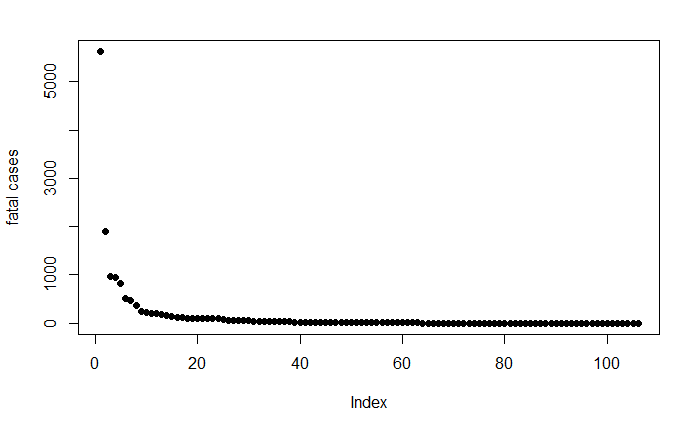

From the plot, we see there are several event types, that has the most of fatal cases. To get the list of the events, that have the most impact, I will be using 80% rule, keep those types, that in total produce 80% of all the fatal cases.

```r
topfatal <- by_type %>%
  mutate(cumsum.prop = cumsum(fatal)/sum(fatal)) %>%
  filter(cumsum.prop <= 0.8)
topfatal
```

| EVTYPE | injury | fatal | cumsum.prop |
| --- | --- | --- | --- |
| TORNADO | 91346 | 5633 | 0.3770667 |
| EXCESSIVE HEAT | 6525 | 1903 | 0.5044514 |
| FLASH FLOOD | 1777 | 978 | 0.5699177 |
| HEAT | 2100 | 937 | 0.6326394 |
| LIGHTNING | 5230 | 816 | 0.6872615 |
| TSTM WIND | 6957 | 504 | 0.7209987 |
| FLOOD | 6789 | 470 | 0.7524600 |
| RIP CURRENT | 232 | 368 | 0.7770935 |
| HIGH WIND | 1137 | 248 | 0.7936944 |

Thus, only 9 event types fit into the criteria, namely: tornado, excessive heat, flash flood, heat, lightning, tstm wind, flood, rip current, high wind